# The scope of infants’ early object word extensions

Zhang Xinyu, Hong Wenjie, Du Guiqin, Wangyan, Xu Jiarong

1

Abstract

Recent research indicates that 6- to 9-month-olds understand a number of object words, but the nature of this understanding is unclear. This work examined whether infants restrict these terms to individual objects (like proper names) or extend them across multiple objects from a category (like common nouns). Experiment 1 reports evidence that 6-month-olds comprehend the name for their mother (e.g., “Mommy”) as restricted to the individual person. Experiment 2 offers support for the claim that 6- and 9-month-olds understand both a label that is restricted to an individual person (e.g., “Mommy”) and a label that extends to multiple members of an object category (i.e., “hand” or “ball”). Experiment 3 provides evidence that 12- to 15-month-olds comprehend both a word that is restricted to an individual (e.g., “Fido”) and a word that extends to multiple category members (e.g., “dog”) for the same object (i.e., a pet dog). The findings indicate that infants understand both individual- and categorical-scope words early in development, suggesting that neither lexical type represents a privileged starting point in word learning. We propose that cross-situational learning abilities, along with intuitive biases to conceptualize objects from particular semantic classes as either individuals or members of categories, play a role in infants’ learning of words of the two lexical types.

```r
# Seed for random number generation
set.seed(42)
knitr::opts_chunk$set(cache.extra = knitr::rand_seed)
```

# 1 Experiment 1

Experiment 1 explored whether infants were able to understand any words with a personal scope, focusing on whether 6-month-old infants restricted their mother’s correct name (e.g. ‘mum’) to the individual caregiver or extended it from the caregiver to another familiar person of a different gender or the same sex.

## 1.1 Objective of Experiment 1

6-month-old infants were assessed whether they would limit their address to their mother (e.g. ‘mum’) to her alone or whether they would extend it to another familiar person, i.e. their father, their grandmother or their maternal aunt/consanguineous female friend.

## 1.2 Data

The experiment was divided into three groups (fathers & grandmothers & aunts), each with a separate experimental and control group. 120 infants, with each subject assigned to any of the 6 groups.

## 1.3 Method

One-way experimental design (infants heard the name of their mother or another familiar person (father, grandmother or aunt)). First, four 10-s long silent familiarization trials were presented to the infant. In each trial, the infant saw a video of a person on one side of the screen (left or right) two familiarization trials showing one adult (mother) and two showing another adult (father, grandmother, or aunt/friend). These trials were randomly arranged to familiarize the infant with the position of each person in the experiment. Next, infants performed four 10-s baseline trials in which a video of the same mother and another familiar adult as in the experimental trials was displayed on the screen and a “look” sound was played during the baseline trials, which was designed to obtain the infant’s visual preference. This was followed by eight 10-s experimental trials in which the same video of the mother and familiar adult were presented, and the word “mom” or the name of another familiar adult was played once at the beginning, 4s, and 7s of each trial.

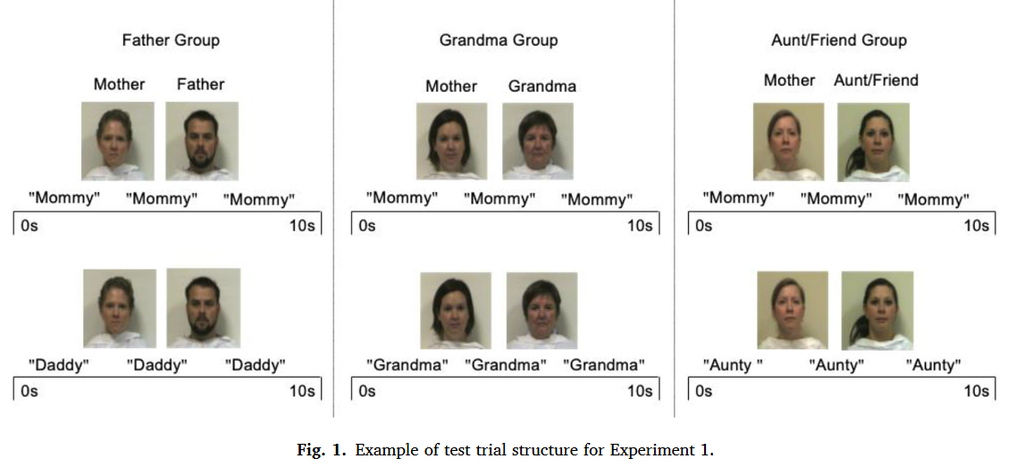

## 1.4 Study replication ideas and results.

### Mother and father groups in experiment 1

```r
# Split the two sheets from the excel table in the original data into 2 csv files, see the data section for details.
df.ex1.FC <-  read.csv('./data/ex1_Father(control).csv', header = T, sep=",", stringsAsFactors = FALSE)
df.ex1.FE<-  read.csv('./data/ex1_Father(exp).csv', header = T, sep=",", stringsAsFactors = FALSE)
colnames(df.ex1.FE)[4] <- "Name.for.Other_Adult"
colnames(df.ex1.FC)[4] <- "Name.for.Other_Adult"
## Calculate the mean of the Father (exp) group
df.ex1.FE.mean <- colMeans(df.ex1.FE[1:20,3:4],na.rm = TRUE)
df.ex1.FE.sd<-apply(df.ex1.FE[1:20,3:4],2,sd,na.rm = TRUE)
##Calculate the average of the Father (control) group
df.ex1.FC.mean <- colMeans(df.ex1.FC[1:20,3:4],na.rm = TRUE)
df.ex1.FC.sd<-apply(df.ex1.FC[1:20,3:4],2,sd,na.rm = TRUE)
```

```r
## Load the package
library(pacman)
pacman::p_load("tidyverse", "bruceR","BayesFactor")
## One-sample t-test of the length of gaze of the mother's video in the experimental group against mean 0 (baseline)
result.ttest1 <- capture.output({
  bruceR::TTEST(data=df.ex1.FE,
                y="Name.for.Mother",
                test.value = 0,
                test.sided = "=",
                file = "./data/FEM_t.doc"
  )
})
## Single-sample t-test of the duration of gaze of the father's video in the experimental group against mean 0 (baseline)
result.ttest1 <- capture.output({
  bruceR::TTEST(data=df.ex1.FE,
                y="Name.for.Other_Adult",
                test.value = 0,
                test.sided = "=",
                file = "./data/FEF_t.doc"
  )
})
## One-sample t-test for length of gaze on mother's video vs. mean 0 (baseline) in control group
result.ttest1 <- capture.output({
  bruceR::TTEST(data=df.ex1.FC,
                y="Name.for.Mother",
                test.value = 0,
                test.sided = "=",
                file = "./data/FCM_t.doc"
  )
})
## One-sample t-test for length of gaze on father's video vs. mean 0 (baseline) in control group
result.ttest1 <- capture.output({
  bruceR::TTEST(data=df.ex1.FC,
                y="Name.for.Other_Adult",
                test.value = 0,
                test.sided = "=",
                file = "./data/FCF_t.doc"
  )
})
```

```r
## Mother and grandmother groups in Experiment 1
## Split the two sheets in the excel table from the original data into 2 csv files, see data section for details
df.ex1.GE<-  read.csv('./data/Grandma Group (Exp).csv',
                      header = T, sep=",", stringsAsFactors = FALSE)
df.ex1.GC<-  read.csv('./data/Grandma Group (Control).csv',
                      header = T, sep=",", stringsAsFactors = FALSE)
df.ex1.GE<-df.ex1.GE[2:21,2:4]
df.ex1.GC<-df.ex1.GC[2:21,2:4]
colnames(df.ex1.GE)[3] <- "Name.for.Other_Adult"
colnames(df.ex1.GC)[3] <- "Name.for.Other_Adult"
## Calculate the mean of the Grandma (exp) group
df.ex1.GE$Name.for.Mother <- as.numeric(df.ex1.GE$Name.for.Mother)
df.ex1.GE$Name.for.Other_Adult<- as.numeric(df.ex1.GE$Name.for.Other_Adult)
df.ex1.GC$Name.for.Mother <- as.numeric(df.ex1.GC$Name.for.Mother)
df.ex1.GC$Name.for.Other_Adult <- as.numeric(df.ex1.GC$Name.for.Other_Adult)
df.ex1.GE.mean <- colMeans(df.ex1.GE[1:20,1:3],na.rm = TRUE)
df.ex1.GE.sd<-apply(df.ex1.GE[1:20,1:3],2,sd,na.rm = TRUE)
## Calculate the mean for the Grandma (control) group
df.ex1.GC.mean <- colMeans(df.ex1.GC[1:20,1:3],na.rm = TRUE)
df.ex1.GC.sd<-apply(df.ex1.GC[1:20,1:3],2,sd,na.rm = TRUE)
## Perform a one-sample t-test of the duration of the mother's video gaze in the experimental group against the mean 0 (baseline)
result.ttest1 <- capture.output({
  bruceR::TTEST(data=df.ex1.GE,
                y="Name.for.Mother",
                test.value = 0,
                test.sided = "=",
                file = "./data/GEM_t.doc"
  )
})
```

### Mother and grandmother groups in Experiment 1

```r
## One-sample t-test of the duration of gaze for the Grandma video in the experimental group versus mean 0 (baseline)
result.ttest1 <- capture.output({
  bruceR::TTEST(data=df.ex1.GE,
                y="Name.for.Other_Adult",
                test.value = 0,
                test.sided = "=",
                file = "./data/GEG_t.doc"
  )
})
## One-sample t-test for length of gaze vs. mean 0 (baseline) for the mother's video in the control group
result.ttest1 <- capture.output({
  bruceR::TTEST(data=df.ex1.GC,
                y="Name.for.Mother",
                test.value = 0,
                test.sided = "=",
                file = "./data/GCM_t.doc"
  )
})
## One-sample t-test of gaze duration vs. mean 0 (baseline) for Grandma's video in control group
result.ttest1 <- capture.output({
  bruceR::TTEST(data=df.ex1.GC,
                y="Name.for.Other_Adult",
                test.value = 0,
                test.sided = "=",
                file = "./data/GCG_t.doc"
  )
})
```

### Mother and aunt groups in Experiment 1

```r
## Split the two sheets from the excel table in the original data into 2 csv files, see data section for details
df.ex1.AE<-  read.csv('./data/Exp1_AF.csv',
                      header = T, sep=",", stringsAsFactors = FALSE)
df.ex1.AC<-  read.csv('./data/Con1_AF.csv',
                      header = T, sep=",", stringsAsFactors = FALSE)
colnames(df.ex1.AE)[4] <- "Name.for.Mother"
colnames(df.ex1.AE)[5] <- "Name.for.Other_Adult"
colnames(df.ex1.AC)[4] <- "Name.for.Mother"
colnames(df.ex1.AC)[5] <- "Name.for.Other_Adult"
## Calculate the mean of the Aunt (exp) group
df.ex1.AE.mean <- colMeans(df.ex1.AE[1:20,3:5],na.rm = TRUE)
df.ex1.AE.sd<-apply(df.ex1.AE[1:20,3:5],2,sd,na.rm = TRUE)
## Calculate the mean of the Aunt (control) group
df.ex1.GC.mean <- colMeans(df.ex1.AC[1:20,3:5],na.rm = TRUE)
df.ex1.GC.sd<-apply(df.ex1.AC[1:20,3:5],2,sd,na.rm = TRUE)
```

```r
## Perform a one-sample t-test of the duration of the mother's video gaze in the experimental group against the mean 0 (baseline)
result.ttest1 <- capture.output({
  bruceR::TTEST(data=df.ex1.AE,
                y="Name.for.Mother",
                test.value = 0,
                test.sided = "=",
                file = "./data/AEM_t.doc"
  )
})

## One-sample t-test of the length of gaze of Aunt's video in the experimental group versus mean 0 (baseline)
result.ttest1 <- capture.output({
  bruceR::TTEST(data=df.ex1.AE,
                y="Name.for.Other_Adult",
                test.value = 0,
                test.sided = "=",
                file = "./data/AEA_t.doc"
  )
})
## One-sample t-test for length of gaze vs. mean 0 (baseline) for Mom's video in the control group
result.ttest1 <- capture.output({
  bruceR::TTEST(data=df.ex1.AC,
                y="Name.for.Mother",
                test.value = 0,
                test.sided = "=",
                file = "./data/ACM_t.doc"
  )
})
## One-sample t-test of the length of gaze of the Aunta video in the control group against mean 0 (baseline)
result.ttest1 <- capture.output({
  bruceR::TTEST(data=df.ex1.AC,
                y="Name.for.Other_Adult",
                test.value = 0,
                test.sided = "=",
                file = "./data/ACA_t.doc"
  )
})
```

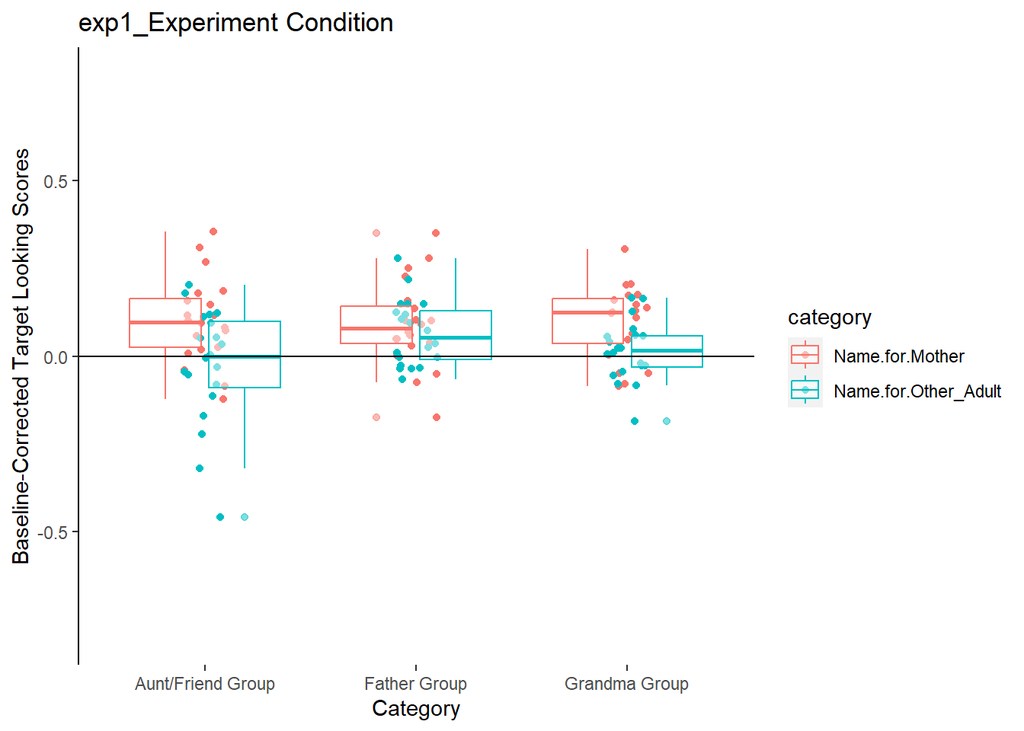

```r
library(ggplot2)
library(dplyr)
library(tidyr)
## Plot the graph
df.ex1.FE$group <- "Father Group"
df.ex1.FC$group<- "Father Group"
df.ex1.GE$group <- "Grandma Group"
df.ex1.GC$group <- "Grandma Group"
df.ex1.AE$group <- "Aunt/Friend Group"
df.ex1.AC$group <- "Aunt/Friend Group"
df_merged.exp<- bind_rows(select(df.ex1.FE, Name.for.Mother, Name.for.Other_Adult,group),
                       select(df.ex1.GE, Name.for.Mother, Name.for.Other_Adult,group),
                       select(df.ex1.AE, Name.for.Mother,Name.for.Other_Adult,group))
df_merged.con<- bind_rows(select(df.ex1.FC,Name.for.Mother,Name.for.Other_Adult,group),
                        select(df.ex1.GC, Name.for.Mother, Name.for.Other_Adult,group),
                        select(df.ex1.AC, Name.for.Mother,Name.for.Other_Adult,group))
c<-gather(df_merged.exp, "category", "score", -group)
d<-gather(df_merged.con, "category", "score", -group)
## Plot superimposed box plots and scatter plots using ggplot2
ggplot(c,aes(x=group,y=score,colour=category))+
  geom_point(position = position_jitter(width = 0.1))+
  geom_boxplot(alpha=0.5)+
  xlab("Category")+
  ylab("Baseline-Corrected Target Looking Scores")+
  ggtitle("exp1_Experiment Condition")+
  ylim(-0.8,0.8)+
  geom_hline(yintercept = 0,size=0.5)+
  theme(panel.background = element_blank(),panel.grid = element_blank(),axis.line.y = element_line(),
        axis.text.y = element_text(),axis.ticks.y = element_line())
```

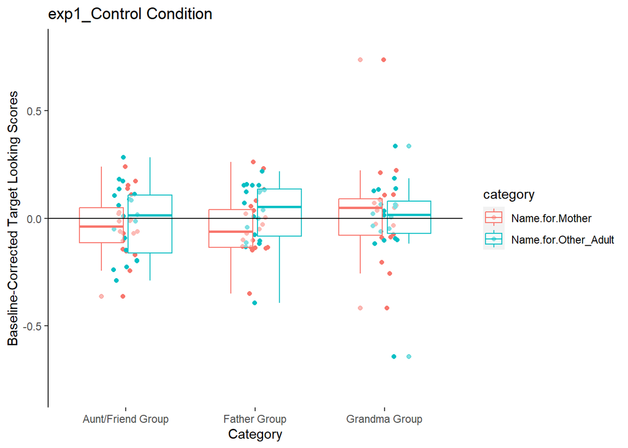

```r
## Plot control group
ggplot(d,aes(x=group,y=score,colour=category))+
  geom_point(position = position_jitter(width = 0.1))+
  geom_boxplot(alpha=0.5)+
  xlab("Category")+
  ylab("Baseline-Corrected Target Looking Scores")+
  ggtitle("exp1_Control Condition")+
  ylim(-0.8,0.8)+
  geom_hline(yintercept = 0,size=0.5)+
  theme(panel.background = element_blank(),panel.grid = element_blank(),axis.line.y = element_line(),
        axis.text.y = element_text(),axis.ticks.y = element_line())
```